# Practical Machine Learning Final Project

Shekhar nagendra

Oct 17, 2016

### Introduction

Using devices such as Jawbone Up, Nike FuelBand, and Fitbit it is now possible to collect a large amount of data about personal activity relatively inexpensively. These type of devices are part of the quantified self movement - a group of enthusiasts who take measurements about themselves regularly to improve their health, to find patterns in their behavior, or because they are tech geeks. One thing that people regularly do is quantify how much of a particular activity they do, but they rarely quantify how well they do it.

In this project, we will use data from accelerometers on the belt, forearm, arm, and dumbell of 6 participants. They were asked to perform barbell lifts correctly and incorrectly in 5 different ways. The five ways are:

- exactly according to the specification (Class A),
- throwing the elbows to the front (Class B),
- lifting the dumbbell only halfway (Class C),
- lowering the dumbbell only halfway (Class D) and
- throwing the hips to the front (Class E).

Only Class A corresponds to correct performance.

The goal of this project is to predict the manner in which they did the exercise, i.e., Class A to E.

More information is available from the website here: http://groupware.les.inf.puc-rio.br/har (see the section on the Weight Lifting Exercise Dataset).

### Load Libraries

```r
library(knitr)
library(caret)
library(rattle)
library(rpart)
library(rpart.plot)
library(kernlab)
```

### Read the Data

```r
# Read the data and remove NA and DIV/0

training_df0 = read.csv("pml-training.csv",header = TRUE, sep = ",",na.strings = c("NA", "#DIV/0!"))


testing_df0 = read.csv("pml-testing.csv",header = TRUE, sep = ",",na.strings = c("NA", "#DIV/0!"))

dim(training_df0)
```

```
## [1] 19622   160
```

### Clean the Data

Looking at the data, many columns have NA. We will remove all those useless columns. Also, columns 1 through 7 have general timestamp and other information irrelevent to our analysis So we will remove columns 1-7 as well

```r
training_df1 <- training_df0[, colSums(is.na(training_df0)) == 0]

# remove column1 1-7
training_df1 <- training_df1[,-c(1:7)]

testing_df1 <- testing_df0[, colSums(is.na(testing_df0)) == 0]
testing_df1 <- testing_df1[,-c(1:7)]


dim(training_df1)
```

```
## [1] 19622    53
```

We have now reduced columns from 160 to 53. Next we check that the resulting data frame has no missing values, and all predictor variables are numeric or integer (except classe which is a factor), with:

```r
table(complete.cases(training_df1)) # result is TRUE
```

```
##
##  TRUE
## 19622
```

```r
table(complete.cases(testing_df1))
```

```
##
## TRUE
##   20
```

```r
table(sapply(training_df1[,], class)) # result is 1 factor and rest numeric/integer
```

```
##
##  factor integer numeric
##       1      25      27
```

```r
table(sapply(testing_df1[,], class)) # result is all integer/numeric
```

```
##
## integer numeric
##      29      24
```

### Split the data

Create partitions of the data into training and validation data sets 70% to 30%

```r
inTrain <- createDataPartition(y=training_df1$classe, p=.7, list=FALSE)

training <-   training_df1[inTrain,]
validation <- training_df1[-inTrain,]
```

### Create Prediction models

We will use the caret package and fit three different classification models (since this is a classification problem) and then choose the best one The three models we will fit are: Random partitions, Boosting, and Random Forests

```r
# Setup cv (cross-validation) parameters
control <- trainControl(method = "cv",number=5)
proc_start <- proc.time()
# Random Partitions model
set.seed(111)
model_rpart <- train(classe ~ ., data=training,
                  preProcess=c("center","scale"),method="rpart",trControl=control)
proc_rpart <-proc.time() - proc_start
proc_rpart
```

```
##    user  system elapsed
##    9.08    0.32    9.50
```

```r
# Generalized Boosting model
set.seed(112)
proc_start <- proc.time()
model_gbm <- train(classe ~ ., data=training,
                  preProcess=c("center","scale"),method="gbm",trControl=control,verbose=FALSE)


proc_gbm <- proc.time() - proc_start
proc_gbm
```

```
##    user  system elapsed
##  395.47    0.90  405.85
```

```r
# Random Forests model
set.seed(113)
proc_start <- proc.time()
model_rf <- train(classe ~ ., data=training,
                  preProcess=c("center","scale"),method="rf",trControl=control)
proc_rf <- proc.time() - proc_start
proc_rf
```

```
##    user  system elapsed
##  867.95    4.38  887.47
```

#### Choose the best Model

```r
pred_rpart <- predict(model_rpart, newdata=validation)
cm_rpart <- confusionMatrix(pred_rpart, validation$classe)

pred_gbm <- predict(model_gbm, newdata=validation)
cm_gbm <- confusionMatrix(pred_gbm, validation$classe)

pred_rf <- predict(model_rf, newdata=validation)
cm_rf <- confusionMatrix(pred_rf, validation$classe)

accuracy_table <- data.frame(model_name = c('RPART', 'GBM', 'RF'),
                  Accuracy = rbind(cm_rpart$overall[1], cm_gbm$overall[1], cm_rf$overall[1])
                  )

accuracy_table
```

```
##   model_name  Accuracy
## 1      RPART 0.4946474
## 2        GBM 0.9631266
## 3         RF 0.9926933
```

- Random partitions (rpart) accuracy is less than 50% so it is worse than a coin toss
- Boosting and Random Forest are much better at over 95% accuracy
- **Random Forests is the best since it has the highest accuracy, so we choose rf**

```r
model_rf
```

```
## Random Forest
##
## 13737 samples
##    52 predictor
##     5 classes: 'A', 'B', 'C', 'D', 'E'
##
## Pre-processing: centered (52), scaled (52)
## Resampling: Cross-Validated (5 fold)
## Summary of sample sizes: 10989, 10991, 10989, 10991, 10988
## Resampling results across tuning parameters:
##
##   mtry  Accuracy   Kappa
##    2    0.9904640  0.9879361
##   27    0.9907551  0.9883056
##   52    0.9831105  0.9786340
##
## Accuracy was used to select the optimal model using  the largest value.
## The final value used for the model was mtry = 27.
```

```r
cm_rf
```

```
## Confusion Matrix and Statistics
##
##           Reference
## Prediction    A    B    C    D    E
##          A 1673    9    0    0    0
##          B    1 1128    4    0    1
##          C    0    2 1021   18    6
##          D    0    0    1  945    0
##          E    0    0    0    1 1075
##
## Overall Statistics
##
##                Accuracy : 0.9927
##                  95% CI : (0.9902, 0.9947)
##     No Information Rate : 0.2845
##     P-Value [Acc > NIR] : < 2.2e-16
##
##                   Kappa : 0.9908
##  Mcnemar's Test P-Value : NA
##
## Statistics by Class:
##
##                      Class: A Class: B Class: C Class: D Class: E
## Sensitivity            0.9994   0.9903   0.9951   0.9803   0.9935
## Specificity            0.9979   0.9987   0.9946   0.9998   0.9998
## Pos Pred Value         0.9946   0.9947   0.9752   0.9989   0.9991
## Neg Pred Value         0.9998   0.9977   0.9990   0.9962   0.9985
## Prevalence             0.2845   0.1935   0.1743   0.1638   0.1839
## Detection Rate         0.2843   0.1917   0.1735   0.1606   0.1827
## Detection Prevalence   0.2858   0.1927   0.1779   0.1607   0.1828
## Balanced Accuracy      0.9986   0.9945   0.9949   0.9900   0.9967
```

Another benefit of random forest model is that it clearly provides a list of the most important variables for predicting the model. Let us see what these are:

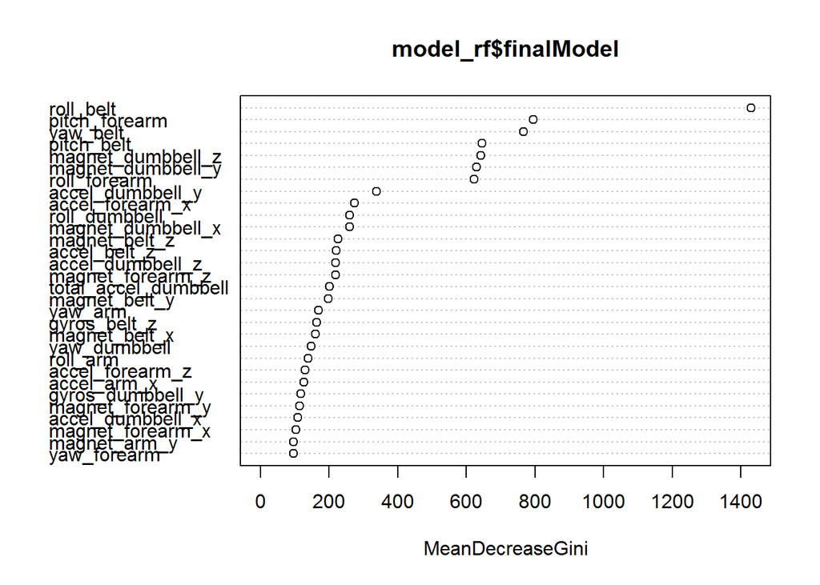

```r
varImpPlot(model_rf$finalModel,type=2)
```

#### Prediction on Testing data

We now use the random forests model we created to predict the outcome variable classe for the testing set and store in the “predictions” vector

```r
predictions <- predict(model_rf,newdata=testing_df1)
## predict will automatically apply predict.train and hence center & scale testing_df1

# now create a data frame of problem_id (from testing_df1) and our predicted value
predicted_df <- data.frame(problem_id=testing_df1$problem_id, predicted_classe=predictions)

predicted_df
```

```
##    problem_id predicted_classe
## 1           1                B
## 2           2                A
## 3           3                B
## 4           4                A
## 5           5                A
## 6           6                E
## 7           7                D
## 8           8                B
## 9           9                A
## 10         10                A
## 11         11                B
## 12         12                C
## 13         13                B
## 14         14                A
## 15         15                E
## 16         16                E
## 17         17                A
## 18         18                B
## 19         19                B
## 20         20                B
```

#### Conclusion

In conclusion, after reviewing the three machine learning algorithms listed above, Random Forest provided the greatest accuracy so this was the chosen model to predict the test data